# Data Set Information:

info source: https://archive.ics.uci.edu/ml/datasets/automobile

This data set consists of three types of entities: (a) the specification of an auto in terms of various characteristics, (b) its assigned insurance risk rating, (c) its normalized losses in use as compared to other cars. The second rating corresponds to the degree to which the auto is more risky than its price indicates. Cars are initially assigned a risk factor symbol associated with its price. Then, if it is more risky (or less), this symbol is adjusted by moving it up (or down) the scale. Actuarians call this process "symboling". A value of +3 indicates that the auto is risky, -3 that it is probably pretty safe.

The third factor is the relative average loss payment per insured vehicle year. This value is normalized for all autos within a particular size classification (two-door small, station wagons, sports/speciality, etc...), and represents the average loss per car per year.

Note: Several of the attributes in the database could be used as a "class" attribute.

data download location: https://archive.ics.uci.edu/ml/machine-learning-databases/autos/imports-85.data

```python
# seems columns didn't have their name so I gave them the names corresponding to their order (from the data's info source link)
import pandas as pd
column_names = ['symboling', 'normalized-losses', 'make', 'fuel-type',
                'aspiration', 'num-of-doors', 'body-style', 'drive-wheels',
                'engine-location', 'wheel-base', 'length', 'width', 'height',
                'curb-weight', 'engine-type', 'num-of-cylinders', 'engine-size',
                'fuel-system', 'bore', 'stroke', 'compression-ratio', 'horsepower',
                'peak-rpm', 'city-mpg', 'highway-mpg', 'price']
cars_df = pd.read_csv('imports-85.data', names=column_names)
print(cars_df.columns)
```

```
Index(['symboling', 'normalized-losses', 'make', 'fuel-type', 'aspiration',
       'num-of-doors', 'body-style', 'drive-wheels', 'engine-location',
       'wheel-base', 'length', 'width', 'height', 'curb-weight', 'engine-type',
       'num-of-cylinders', 'engine-size', 'fuel-system', 'bore', 'stroke',
       'compression-ratio', 'horsepower', 'peak-rpm', 'city-mpg',
       'highway-mpg', 'price'],
      dtype='object')
```

# Columns & Their Possible Values

1.** symboling**: -3, -2, -1, 0, 1, 2, 3.

2.** normalized-losses**: continuous from 65 to 256.

3.** make**: alfa-romero, audi, bmw, chevrolet, dodge, honda, isuzu, jaguar, mazda, mercedes-benz, mercury, mitsubishi, nissan, peugot, plymouth, porsche, renault, saab, subaru, toyota, volkswagen, volvo

4.** fuel-type**: diesel, gas.

5.** aspiration**: std, turbo.

6.** num-of-doors**: four, two.

7.** body-style**: hardtop, wagon, sedan, hatchback, convertible.

8.** drive-wheels**: 4wd, fwd, rwd.

9.** engine-location**: front, rear.

10.** wheel-base**: continuous from 86.6 120.9.

11.** length**: continuous from 141.1 to 208.1.

12.** width**: continuous from 60.3 to 72.3.

13.** height**: continuous from 47.8 to 59.8.

14.** curb-weight**: continuous from 1488 to 4066.

15.** engine-type**: dohc, dohcv, l, ohc, ohcf, ohcv, rotor.

16.** num-of-cylinders**: eight, five, four, six, three, twelve, two.

17.** engine-size**: continuous from 61 to 326.

18.** fuel-system**: 1bbl, 2bbl, 4bbl, idi, mfi, mpfi, spdi, spfi.

19.** bore**: continuous from 2.54 to 3.94.

20.** stroke**: continuous from 2.07 to 4.17.

21.** compression-ratio**: continuous from 7 to 23.

22.** horsepower**: continuous from 48 to 288.

23.** peak-rpm**: continuous from 4150 to 6600.

24.** city-mpg**: continuous from 13 to 49.

25.** highway-mpg**: continuous from 16 to 54.

26.** price**: continuous from 5118 to 45400.

```python
# What does the ACTUAL data look like?
cars_df.head(5)
```

|  | symboling | normalized-losses | make | fuel-type | aspiration | num-of-doors | body-style | drive-wheels | engine-location | wheel-base | ... | engine-size | fuel-system | bore | stroke | compression-ratio | horsepower | peak-rpm | city-mpg | highway-mpg | price |
| --- | --- | --- | --- | --- | --- | --- | --- | --- | --- | --- | --- | --- | --- | --- | --- | --- | --- | --- | --- | --- | --- |
| 0 | 3 | ? | alfa-romero | gas | std | two | convertible | rwd | front | 88.6 | ... | 130 | mpfi | 3.47 | 2.68 | 9.0 | 111 | 5000 | 21 | 27 | 13495 |
| 1 | 3 | ? | alfa-romero | gas | std | two | convertible | rwd | front | 88.6 | ... | 130 | mpfi | 3.47 | 2.68 | 9.0 | 111 | 5000 | 21 | 27 | 16500 |
| 2 | 1 | ? | alfa-romero | gas | std | two | hatchback | rwd | front | 94.5 | ... | 152 | mpfi | 2.68 | 3.47 | 9.0 | 154 | 5000 | 19 | 26 | 16500 |
| 3 | 2 | 164 | audi | gas | std | four | sedan | fwd | front | 99.8 | ... | 109 | mpfi | 3.19 | 3.40 | 10.0 | 102 | 5500 | 24 | 30 | 13950 |
| 4 | 2 | 164 | audi | gas | std | four | sedan | 4wd | front | 99.4 | ... | 136 | mpfi | 3.19 | 3.40 | 8.0 | 115 | 5500 | 18 | 22 | 17450 |

5 rows × 26 columns

```python
cars_df.info()
```

```
<class 'pandas.core.frame.DataFrame'>
RangeIndex: 205 entries, 0 to 204
Data columns (total 26 columns):
symboling            205 non-null int64
normalized-losses    205 non-null object
make                 205 non-null object
fuel-type            205 non-null object
aspiration           205 non-null object
num-of-doors         205 non-null object
body-style           205 non-null object
drive-wheels         205 non-null object
engine-location      205 non-null object
wheel-base           205 non-null float64
length               205 non-null float64
width                205 non-null float64
height               205 non-null float64
curb-weight          205 non-null int64
engine-type          205 non-null object
num-of-cylinders     205 non-null object
engine-size          205 non-null int64
fuel-system          205 non-null object
bore                 205 non-null object
stroke               205 non-null object
compression-ratio    205 non-null float64
horsepower           205 non-null object
peak-rpm             205 non-null object
city-mpg             205 non-null int64
highway-mpg          205 non-null int64
price                205 non-null object
dtypes: float64(5), int64(5), object(16)
memory usage: 41.7+ KB
```

```python
# '?' in the data represents missing data
# I'm changing to match pandas missing datatype
import numpy as np
cars_df = cars_df.replace('?', np.nan)
# cars_df.info() # double check debug
```

```python
cars_df['normalized-losses'] = pd.to_numeric(cars_df['normalized-losses'])
cars_df['normalized-losses'].fillna(value=cars_df['normalized-losses'].mean(), inplace=True)
# cars_df.info() # double check debug
```

```python
cars_df.dropna(inplace=True)
# cars_df.info() # double check debug
```

```python
to_convert_to_float = list(cars_df.dtypes[cars_df.dtypes == 'int64'].index)
print(to_convert_to_float)

for col in to_convert_to_float:
    cars_df[col] = cars_df[col].astype(float)

cars_df.info()
```

```
['symboling', 'curb-weight', 'engine-size', 'city-mpg', 'highway-mpg']
<class 'pandas.core.frame.DataFrame'>
Int64Index: 193 entries, 0 to 204
Data columns (total 26 columns):
symboling            193 non-null float64
normalized-losses    193 non-null float64
make                 193 non-null object
fuel-type            193 non-null object
aspiration           193 non-null object
num-of-doors         193 non-null object
body-style           193 non-null object
drive-wheels         193 non-null object
engine-location      193 non-null object
wheel-base           193 non-null float64
length               193 non-null float64
width                193 non-null float64
height               193 non-null float64
curb-weight          193 non-null float64
engine-type          193 non-null object
num-of-cylinders     193 non-null object
engine-size          193 non-null float64
fuel-system          193 non-null object
bore                 193 non-null object
stroke               193 non-null object
compression-ratio    193 non-null float64
horsepower           193 non-null object
peak-rpm             193 non-null object
city-mpg             193 non-null float64
highway-mpg          193 non-null float64
price                193 non-null object
dtypes: float64(11), object(15)
memory usage: 40.7+ KB
```

```python
# Normalize all float (feature) columns
features = ['horsepower', 'peak-rpm', 'price', 'symboling', 'normalized-losses', 'wheel-base',
                'length', 'width', 'height', 'curb-weight', 'engine-size', 'bore', 'stroke',
                'compression-ratio', 'city-mpg', 'highway-mpg']

for col in features:
    cars_df[col] = cars_df[col].astype(float)
    cars_df[col] = cars_df[col] - np.min(cars_df[col])
    span = np.max(cars_df[col]) - np.min(cars_df[col])
    cars_df[col] = cars_df[col] / span
```

# Univariate Model Prediction Function

```python
# create a function to train univariate models
def knn_train_test(df, feature_col, target_col):
    # split test & train
    from sklearn.model_selection import cross_val_score, KFold
    kf = KFold(shuffle=True, random_state=1)

    from sklearn.neighbors import KNeighborsRegressor
    knn = KNeighborsRegressor()
    mses = cross_val_score(estimator=knn, X=df[[feature_col]], y=df[target_col], scoring='neg_mean_squared_error', cv=kf)
    rmses = np.sqrt(np.absolute(mses))
    avg_rmse = np.mean(rmses)
    return avg_rmse
```

```python
# use the function to make a price prediction using all the features
errors = list()
for col in features:
    errors.append(knn_train_test(cars_df, col, 'price'))
print(list(zip(features, errors)))
```

[output not shown]

# Feature Error Values for Price Prediction (Lower = Better)

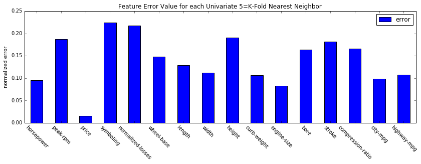

```python
from matplotlib import pyplot as plt
%matplotlib inline
df = pd.DataFrame({'error': errors}, index=features)
df.plot.bar(rot=-45, figsize=(14,4))
plt.ylabel('normalized error')
plt.title('Feature Error Value for each Univariate 5=K-Fold Nearest Neighbor')
plt.show()
```

# Univariate Model Prediction Function w/ K-Nearest as Parameter

```python
# create a function to train univariate models with
# 2nd version allows a parameter to specific how many of the nearest neighbors are averaged
def knn_train_test2(df, feature_col, target_col, k=5):
    # split test & train
    from sklearn.model_selection import cross_val_score, KFold
    kf = KFold(shuffle=True, random_state=1)

    from sklearn.neighbors import KNeighborsRegressor
    knn = KNeighborsRegressor(n_neighbors = k)
    mses = cross_val_score(estimator=knn, X=df[[feature_col]], y=df[target_col], scoring='neg_mean_squared_error', cv=kf)
    rmses = np.sqrt(np.absolute(mses))
    avg_rmse = np.mean(rmses)
    return avg_rmse
```

```python
# use the function to make a price prediction using all the features
# log predictions in to a dict for bar plot later
errors = dict()
k_folds = [1,3,5,7,9]
for k in k_folds:
    errors[k] = []
    for col in features:
        error = knn_train_test2(cars_df, col, 'price', k)
        errors[k].append(error)
```

# Univariate Model Feature Errors for each K-Nearest Tested

[figure not shown]

```python
from matplotlib import pyplot as plt
%matplotlib inline

feature_error_dict = dict()
for key in errors:
    feature_error_dict[str('error k='+str(key))] = errors[key]

df = pd.DataFrame(feature_error_dict, index=features)
df.plot.bar(rot=-45, figsize=(16,4))
plt.ylabel('normalized error')
plt.title('Univariate Model Feature Errors for each K-Nearest Tested ')
plt.show()
```